# E_COMPANY

Step 60: APPLY CHI-SQUARED TEST FOR FEATURE SELECTOR

```python
from sklearn.feature_selection import SelectKBest, chi2
#Apply chi_squred test
chi2_selector = SelectKBest(score_func=chi2, k='all') #Use 'all to see scores for all features
x_train_chi2 = chi2_selector.fit_transform(x_train, y_train)

#Get the scores and selected feature name
chi2_scores = chi2_selector.scores_
chi2_feature_names = x_test.columns[chi2_selector.get_support()]

#Create a DataFrame to display the features and their scores
chi2_results= pd.DataFrame({'Feature': x.columns, 'Chi2 Score': chi2_scores})
chi2_results = chi2_results.sort_values(by='Chi2 Score', ascending=False)
print(chi2_results)
```

```
                     Feature     Chi2 Score
5   Product Related_Duration  591332.772439
8                 PageValues  127605.106887
1    Administrative_Duration   35811.546533
3     Informational_Duration   24841.061284
4             ProductRelated   13139.040569
0             Administrative     889.882500
2              Informational     251.300697
10                     Month      40.385728
9                 SpecialDay      39.204196
15               VisitorType      29.287381
6                BounceRates      20.353428
7                 Exit Rates      19.916683
12                   Browser       8.362534
14               TrafficType       8.351982
16                   Weekend       4.454182
13                    Region       3.155920
11          OperatingSystems       0.591731
```

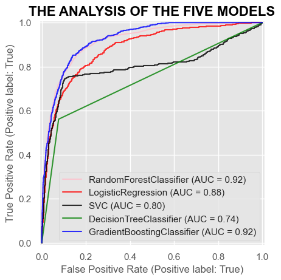

```python
ax = plt.gca()

rf_disp.plot( ax=ax, alpha=0.8, color = 'pink')
lr_disp.plot(ax=ax, alpha=0.8, color = 'red')
svm_disp.plot(ax=ax, alpha=0.8, color = 'black')
dt_disp.plot(ax=ax, alpha=0.8, color = 'green')
gbc_disp.plot(ax=ax, alpha=0.8, color = 'blue')
plt.title("THE ANALYSIS OF THE FIVE MODELS", size = 16, fontweight= 'bold', color='black')
plt.show()
```

Step 62: Import Libriaries for Classificatin metrics

```python
from sklearn.metrics import classification_report, confusion_matrix, accuracy_score,precision_recall_fscore_support, recall_score, precision_score
from sklearn.metrics import f1_score,roc_auc_score
```

Step 63: Classification Metrics for Logistic Regression

```python
print("LOGISTIC REGRESSION:")
print("ACCURACY:", accuracy_score(y_test, lr_pred))
print("PRECISION:", precision_score(y_test, lr_pred))
print("F1_SCORE:", f1_score(y_test, lr_pred))
print ("RECALL:", recall_score(y_test, lr_pred))
print("ROC:", roc_auc_score(y_test, lr_pred))
```

```
LOGISTIC REGRESSION:
ACCURACY: 0.8718572587185726
PRECISION: 0.75
F1_SCORE: 0.48366013071895425
RECALL: 0.35691318327974275
ROC: 0.666431892257356
```

Step 64: Classification metrics for Random Forest Classifier

```python
print("RANDON FOREST CLASSIFIER:")
print("ACCURACY:", accuracy_score(y_test, rf_pred))
print("PRECISION:", precision_score(y_test, rf_pred))
print("F1_SCORE:", f1_score(y_test, rf_pred))
print ("RECALL:", recall_score(y_test, rf_pred))
print("ROC:", roc_auc_score(y_test, rf_pred))
```

```
RANDON FOREST CLASSIFIER:
ACCURACY: 0.895647472289808
PRECISION: 0.7489451476793249
F1_SCORE: 0.6478102189781022
RECALL: 0.5707395498392283
ROC: 0.7660327583450285
```

Step 65: Classification metrics for Decision Tree Classifier

```python
print("DECISION TREE CLASSIFIER:")
print("ACCURACY:", accuracy_score(y_test, dt_pred))
print("PRECISION:", precision_score(y_test, dt_pred))
print("F1_SCORE:", f1_score(y_test, dt_pred))
print ("RECALL:", recall_score(y_test, dt_pred))
print("ROC:", roc_auc_score(y_test, dt_pred))
```

```
DECISION TREE CLASSIFIER:
ACCURACY: 0.8626655852933225
PRECISION: 0.5976027397260274
F1_SCORE: 0.5787728026533997
RECALL: 0.5610932475884244
ROC: 0.7423600784578457
```

Step 66: Classification Metrics for Support Vector Machine

```python
print("SUPPORT VECTOR MACHINE:")
print("ACCURACY:", accuracy_score(y_test, svm_pred))
print("PRECISION:", precision_score(y_test, svm_pred))
print("F1_SCORE:", f1_score(y_test, svm_pred))
print ("RECALL:", recall_score(y_test, svm_pred))
print("ROC:", roc_auc_score(y_test, svm_pred))
```

```
SUPPORT VECTOR MACHINE:
ACCURACY: 0.8340091916734252
PRECISION: 1.0
F1_SCORE: 0.025396825396825397
RECALL: 0.012861736334405145
ROC: 0.5064308681672026
```

Step 67: Classification metrics for Gradient Boosting Classifier

```python
print("GRADIENT BOOSTING CLASSIFIER:")
print("ACCURACY:", accuracy_score(y_test, gbc_pred))
print("PRECISION:", precision_score(y_test, gbc_pred))
print("F1_SCORE:", f1_score(y_test, gbc_pred))
print ("RECALL:", recall_score(y_test, gbc_pred))
print("ROC:", roc_auc_score(y_test, gbc_pred))
```

```
GRADIENT BOOSTING CLASSIFIER:
ACCURACY: 0.8926736955934036
PRECISION: 0.731006160164271
F1_SCORE: 0.6420198376916141
RECALL: 0.572347266881029
ROC: 0.7648866656147101
```

Step 69: Classification Metrics for Logistic Regession In Percentage

```python
print("LOGISTIC REGRESSION:")
final_data = pd.DataFrame({"CLASSIFICATION":["ACCURACY","PRECISION","F1_SCORE", "RECALL", "ROC"], "PERCENTAGE":
[accuracy_score(y_test, lr_pred)*100,
 precision_score(y_test, lr_pred)*100,
 f1_score(y_test, lr_pred)*100,
 recall_score(y_test, lr_pred)*100,
 roc_auc_score(y_test, lr_pred)*100,]})
final_data
```

```
LOGISTIC REGRESSION:
```

|  | CLASSIFICATION | PERCENTAGE |
| --- | --- | --- |
| 0 | ACCURACY | 87.185726 |
| 1 | PRECISION | 75.000000 |
| 2 | F1_SCORE | 48.366013 |
| 3 | RECALL | 35.691318 |
| 4 | ROC | 66.643189 |

Step 70: Classification Metrics for Random Forest Classifier In Percentage

```python
print("RANDOM FOREST CLASSIFIER:")
final_data = pd.DataFrame({"CLASSIFICATION":["ACCURACY","PRECISION","F1_SCORE", "RECALL", "ROC"], "PERCENTAGE":
[accuracy_score(y_test, rf_pred)*100,
 precision_score(y_test, rf_pred)*100,
 f1_score(y_test, rf_pred)*100,
 recall_score(y_test, rf_pred)*100,
 roc_auc_score(y_test, rf_pred)*100,]})
final_data
```

```
RANDOM FOREST CLASSIFIER:
```

|  | CLASSIFICATION | PERCENTAGE |
| --- | --- | --- |
| 0 | ACCURACY | 89.564747 |
| 1 | PRECISION | 74.894515 |
| 2 | F1_SCORE | 64.781022 |
| 3 | RECALL | 57.073955 |
| 4 | ROC | 76.603276 |

Step 71: Classification Metrics for Decision Tree Classifier In Percentage

```python
print("DECISION TREE CLASSIFIER:")
final_data = pd.DataFrame({"CLASSIFICATION":["ACCURACY","PRECISION","F1_SCORE", "RECALL", "ROC"], "PERCENTAGE":
[accuracy_score(y_test, dt_pred)*100,
 precision_score(y_test, dt_pred)*100,
 f1_score(y_test, dt_pred)*100,
 recall_score(y_test, dt_pred)*100,
 roc_auc_score(y_test, dt_pred)*100,]})
final_data
```

```
DECISION TREE CLASSIFIER:
```

|  | CLASSIFICATION | PERCENTAGE |
| --- | --- | --- |
| 0 | ACCURACY | 86.266559 |
| 1 | PRECISION | 59.760274 |
| 2 | F1_SCORE | 57.877280 |
| 3 | RECALL | 56.109325 |
| 4 | ROC | 74.236008 |

Step 72: Classification Metrics for Support Vector Machine In Percentage

```python
print("SUPPORT VECTOR MACHINE:")
final_data = pd.DataFrame({"CLASSIFICATION":["ACCURACY","PRECISION","F1_SCORE", "RECALL", "ROC"], "PERCENTAGE":
[accuracy_score(y_test, svm_pred)*100,
 precision_score(y_test, svm_pred)*100,
 f1_score(y_test, svm_pred)*100,
 recall_score(y_test, svm_pred)*100,
 roc_auc_score(y_test, svm_pred)*100,]})
final_data
```

```
SUPPORT VECTOR MACHINE:
```

|  | CLASSIFICATION | PERCENTAGE |
| --- | --- | --- |
| 0 | ACCURACY | 83.400919 |
| 1 | PRECISION | 100.000000 |
| 2 | F1_SCORE | 2.539683 |
| 3 | RECALL | 1.286174 |
| 4 | ROC | 50.643087 |

Step 73: Classification Metrics for Gradient Boosting Classifier In Percentage

```python
print("GRADIENT BOOSTING CLASSIFIER:")
final_data = pd.DataFrame({"CLASSIFICATION":["ACCURACY","PRECISION","F1_SCORE", "RECALL", "ROC"], "PERCENTAGE":
[accuracy_score(y_test, gbc_pred)*100,
 precision_score(y_test, gbc_pred)*100,
 f1_score(y_test, gbc_pred)*100,
 recall_score(y_test, gbc_pred)*100,
 roc_auc_score(y_test, gbc_pred)*100,]})
final_data
```

```
GRADIENT BOOSTING CLASSIFIER:
```

|  | CLASSIFICATION | PERCENTAGE |
| --- | --- | --- |
| 0 | ACCURACY | 89.267370 |
| 1 | PRECISION | 73.100616 |
| 2 | F1_SCORE | 64.201984 |
| 3 | RECALL | 57.234727 |
| 4 | ROC | 76.488667 |